# Activity: Bird Species

Jonathan Jackson

2/24/2022

# Set Up

```r
# Load `tidyverse` and `dcData` packages

library(tidyverse)
library(dcData)
library(mosaic)


# Load the `OrdwayBirds` data set into your RStudio environment from the `dcData` package

data(OrdwayBirds)


# Show a few commands used to inspect the data set a few different ways

view(OrdwayBirds)
help(OrdwayBirds)
summary(OrdwayBirds)
```

```
    bogus            Timestamp             Year               Day               Month           CaptureTime        SpeciesName
 Length:15829       Length:15829       Length:15829       Length:15829       Length:15829       Length:15829       Length:15829
 Class :character   Class :character   Class :character   Class :character   Class :character   Class :character   Class :character
 Mode  :character   Mode  :character   Mode  :character   Mode  :character   Mode  :character   Mode  :character   Mode  :character
     Sex                Age             BandNumber           TrapID            Weather          BandingReport      RecaptureYN
 Length:15829       Length:15829       Length:15829       Length:15829       Length:15829       Length:15829       Length:15829
 Class :character   Class :character   Class :character   Class :character   Class :character   Class :character   Class :character
 Mode  :character   Mode  :character   Mode  :character   Mode  :character   Mode  :character   Mode  :character   Mode  :character
 RecaptureMonth     RecaptureDay        Condition           Release            Comments         DataEntryPerson       Weight
 Length:15829       Length:15829       Length:15829       Length:15829       Length:15829       Length:15829       Length:15829
 Class :character   Class :character   Class :character   Class :character   Class :character   Class :character   Class :character
 Mode  :character   Mode  :character   Mode  :character   Mode  :character   Mode  :character   Mode  :character   Mode  :character
  WingChord         Temperature        RecaptureOriginal  RecapturePrevious   TailLength
 Length:15829       Length:15829       Length:15829       Length:15829       Length:15829
 Class :character   Class :character   Class :character   Class :character   Class :character
 Mode  :character   Mode  :character   Mode  :character   Mode  :character   Mode  :character
```

# Activity

When you’re finished with this activity, you will have a graph that shows what time of year various species appear at the Katherine Ordway Natural History Study Area in Inver Grove Heights, MN.

### Step 0

Before we begin, the book gives us some instructions to select a few key variables and clean up the date formatting. Use the commands given in the book, but be sure to study the functions used so you know what is happening. In this case, we select `SpeciesName`, `Month`, and `Day`. Then a `mutate()` command converts each variable to character, and then converts the resulting “character string” to a number.

```r
# Get the data table & clean up dates (see Data Computing eBook)

OrdwayBirds <-
  OrdwayBirds %>%
  select( SpeciesName, Month, Day ) %>%
  mutate( Month = as.numeric(as.character(Month)),
          Day = as.numeric(as.character(Day)))


# Inspect resulting data

OrdwayBirds
```

|  | SpeciesName | Month | Day |
| --- | --- | --- | --- |
| 3 | Song Sparrow | 7 | 16 |
| 4 |  | NA | NA |
| 5 | Song Sparrow | 7 | 16 |
| 6 | Field Sparrow | 7 | 16 |
| 7 | Field Sparrow | 7 | 16 |
| 8 | Song Sparrow | 7 | 16 |
| 9 | Field Sparrow | 7 | 16 |
| 10 | Song Sparrow | 7 | 16 |
| 11 | Field Sparrow | 7 | 16 |
| 12 | House Sparrow | 7 | 16 |

[output cut: 990 more lines]

### Step 1

```r
# unique species in original data (including mis-spellings)

OrdwayBirds %>%
  summarise(uniqueSpecies = n_distinct(SpeciesName))
```

| uniqueSpecies |
| --- |
| 275 |

```r
# unique species in the clean list

OrdwaySpeciesNames %>%
  summarise(count = n_distinct(SpeciesNameCleaned))
```

| count |
| --- |
| 109 |

```r
NA
```

275 is the # of unique species in the original data set. In the clean list, the count is now 109.

### Step 2

```r
# inspect OrdwaySpeciesNames
summary(OrdwaySpeciesNames)
```

```
 SpeciesName        SpeciesNameCleaned
 Length:265         Length:265
 Class :character   Class :character
 Mode  :character   Mode  :character
```

```r
# inner join
Corrected <-
  OrdwayBirds %>%
  inner_join( OrdwaySpeciesNames ) %>%
  select( Species = SpeciesNameCleaned, Month, Day ) %>%
  na.omit()
# inspect the data after the join

View(Corrected)
summary(Corrected)
```

```
   Species              Month             Day
 Length:15144       Min.   : 1.000   Min.   :   1.00
 Class :character   1st Qu.: 5.000   1st Qu.:   8.00
 Mode  :character   Median : 7.000   Median :  15.00
                    Mean   : 7.113   Mean   :  15.55
                    3rd Qu.:10.000   3rd Qu.:  23.00
                    Max.   :25.000   Max.   :1975.00
```

The first data table is OrdwaySpeciesNames. It contains two variables: `SpeciesName` and `SpeciesNameCleaned`. We will continue to use `SpeciesNameCleaned` for the remainder of this activity.

The second data table is Corrected. It contains three variables: `Species`, `Month`, and `Day`. This table is a combination of the OrdwayBirds and the OrdwaySpeciesNames data tables. These two tables were joined together in order to correct the spelling errors of the species names in the OrdwayBirds data table.

### Step 3

We want to identify the top 5-6 bird species sighted at the Katherine Ordway Natural History Study Area.

```r
# count sightings by species in descending order

sightingspecies <-
  Corrected %>%
  group_by(Species) %>%
  summarise(count=n()) %>%
  arrange(desc(count))

sightingspecies
```

| Species | count |
| --- | --- |
| Slate-colored Junco | 2732 |
| Tree Swallow | 1537 |
| Black-capped Chickadee | 1327 |
| American Goldfinch | 1204 |
| Field Sparrow | 1164 |
| Lincoln's Sparrow | 790 |
| Robin | 608 |
| Catbird | 554 |
| Song Sparrow | 512 |
| House Wren | 460 |

[output cut: 98 more lines]

```r
# a hint on p.164 recommends displaying the top 10 species to choose our threshold

numSightingsTop <-
  Corrected %>%
  group_by(Species) %>%
  summarise(count = n()) %>%
  arrange(desc(count)) %>%
  head(10)
numSightingsTop
```

| Species | count |
| --- | --- |
| Slate-colored Junco | 2732 |
| Tree Swallow | 1537 |
| Black-capped Chickadee | 1327 |
| American Goldfinch | 1204 |
| Field Sparrow | 1164 |
| Lincoln's Sparrow | 790 |
| Robin | 608 |
| Catbird | 554 |
| Song Sparrow | 512 |
| House Wren | 460 |

```r
# define a sightings threshold; produce a table with only birds belonging to major species

Majors <-
  Corrected %>%
  group_by(Species) %>%
  summarise(Count = n(), Major = FALSE) %>%
  mutate(Major = ifelse(Count > 1000, TRUE, Major)) %>%
  filter(Major == TRUE) %>%
  arrange(desc(Count))

Majors
```

| Species | Count | Major |
| --- | --- | --- |
| Slate-colored Junco | 2732 | TRUE |
| Tree Swallow | 1537 | TRUE |
| Black-capped Chickadee | 1327 | TRUE |
| American Goldfinch | 1204 | TRUE |
| Field Sparrow | 1164 | TRUE |

```r
NA
NA
```

The first table uses two variables species and count and it represents the number of sightings by species. There are 108 species in the table. In the second table we wanted to get the top 10 sightings so there are only 10 species listed in the table. In the third table, a new variable, `Major`, is added which is a Boolean variable representing whether or not a species is considered Major. To be considered Major, a species must have been seen at least 1,000 times. By filtering for species that are Major, there are now only five species in the table.

### Step 4

We now want to produce a month-by-month count for each of the major species, and then construct a chart to tell the story of what time of year the various species appear.

```r
# prepare glyph-ready data table called `ByMonth`

ByMonth <-
  Corrected %>%
  left_join(Majors) %>%
  filter(Major == TRUE) %>%
  group_by(Species, Month) %>%
  summarise(Count = n())
ByMonth
```

| Species | Month | Count |
| --- | --- | --- |
| American Goldfinch | 1 | 10 |
| American Goldfinch | 2 | 51 |
| American Goldfinch | 3 | 52 |
| American Goldfinch | 4 | 21 |
| American Goldfinch | 5 | 150 |
| American Goldfinch | 6 | 66 |
| American Goldfinch | 7 | 69 |
| American Goldfinch | 8 | 78 |
| American Goldfinch | 9 | 160 |
| American Goldfinch | 10 | 364 |

[output cut: 42 more lines]

```r
NA
```

Now, using `mplot()` or `esquisser()` in the console, we can configure a reasonable graph and choose “show expression” to get `ggplot2` that can be embedded in our report.

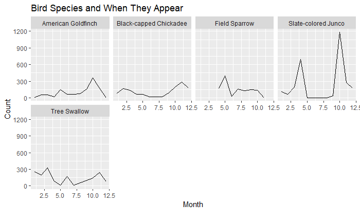

```r
# ggplot command
gf_line(Count ~ Month, data = ByMonth) %>%
  gf_facet_wrap(~ Species, ncol = 4) %>%
  gf_labs(title = "Bird Species and When They Appear", caption = "")
```

[output not shown]

```r
goodNumber <-
  ByMonth %>%
  filter(Count > 100) %>%
  summarise(numMonths = n()) %>%
  filter(numMonths >= 6) %>%
  select(Species)
goodNumber
```

| Species |
| --- |
| Field Sparrow |
| Slate-colored Junco |
| Tree Swallow |

```r
NA
```